# Researching the Factors Behind the Pollution in Bangkok, Thailand

Jieyuan Kan 12/1/2021

```r
library(tidyverse)
```

```r
library(ggplot2)
library(dplyr)
library(httr)
library(jsonlite)
library(tidyr)
library(purrr)
```

#Project Description

Bangkok is the capital, most populous city and chief port of Thailand. The Thailand Meteorological Department divides the climate into three seasons: local summer (mid-February to mid-May), rainy season (mid-May to mid-October), and winter (mid-October to mid-February). Bangkok is a always a beautiful city, but in recent thirty years, the air quality in Bangkok worsens due to the social and economic development. What factors are behind this pollution? Are there any environmental justice problems along the way? I decide to use R and data to probe into the air pollution in Bangkok.

#Description on the Data Sources

1. Air Quality Data (.csv)

The data is from AQICN, i.e. The World Air Quality Index Project (aqicn.org), and it has downloadable historical dataset of air pollution for major cities in the world. I have downloaded the Bangkok air pollution dataset from this platform. This is the hourly air pollutant concentration data from 45 stations in Bangkok from 2017 to 2020. The atmospheric pollutants in the dataset are PM2.5, PM10, CO, NO2, SO2, O3, and it contains a column to show the date (Month-Year, can be transferred to Day-Month-Year).

2. Landfills and Gas Stations Data (shapefiles)

These data are from the one of the programs of Thailand Government, namely Thailand Open Data (data.go.th). Through this platform, I can get data in Bangkok, other areas in Thailand, or Thailand national data in local economy, natural resources, development, transportation, environment, etc. I have downloaded data for the location of landfills, bikeways, gas stations, and population data for this analysis. They are stored in shapefiles.

3. Weather Data

Weather data is from the platform of Open Weather Map (openweathermap.org), a non-profit and educational organization in the UK. By using education email, I can access the historical data back to 2019 (Original membership price is $1500/month, Berkeley education email really saves me a lot!!). The index I am going to use for the analysis includes wind speed, humidity, and precipitation. They are usually reported by scientists that have influences on the air pollution. I will use my API key to call this data.

#Research Questions and Analysis Tasks

1. Which season has an overall higher pollution in 2019? How can you explain that? For 2020, under the COVID-19 pandemic and quarantine requirements from the local governments, is the air quality overall in Bangkok better than 2019?
2. Construction is usually a socio-economic factor which can bring negative impacts on air quality. Bangkok builds a lot of landfills, waste centers, and gas stations. Now map the current landfills and gas stations (both are important air pollution sources) in Bangkok, does the number of these infrastructures correlate with the number of people in their areas? Do you see any environmental justice problems?
3. After the socio-economic factors, now consider the natural factors. For natural factors, these can be geography of Bangkok, or the local weather. Use the natural data to illustrate how they will also influence the Bangkok’s air quality.

#Work

First of all, I import the the air quality data into R.

```r
ap19_full <- read.csv("bangkok-air-quality.csv")
head(ap19_full)
```

```
##     date pm25 pm10 o3 no2 so2 co
## 1 Jan-19   81   40 22  18  NA NA
## 2 Jan-19   88   48 13  20  NA NA
## 3 Jan-19   90   55 13  24   1 NA
## 4 Jan-19  103   62  4  24   1 NA
## 5 Jan-19  117   76 20  20   1 NA
## 6 Jan-19  159   74 21  19  NA NA
```

By checking the dataset, we can find that there are lots of NA values in the column of SO2 and CO. Therefore, I decide to remove the columns of SO2 and CO. The PM2.5, PM10, O3, and NO2 index columns are enough for the air pollution analysis. These four air pollutants usually bring many health problems to the local people.

```r
ap19 <- dplyr::select(ap19_full,c(date, pm25, pm10, o3, no2))
head(ap19)
```

```
##     date pm25 pm10 o3 no2
## 1 Jan-19   81   40 22  18
## 2 Jan-19   88   48 13  20
## 3 Jan-19   90   55 13  24
## 4 Jan-19  103   62  4  24
## 5 Jan-19  117   76 20  20
## 6 Jan-19  159   74 21  19
```

As I want to explore which season has overall higher air pollution, I need to group the raw data by their months to get the monthly data. Below I use group and summarise method to group the data.

```r
ap19sum <- ap19 %>%
  group_by(date) %>%
  summarise(mean_pm25 = mean(pm25),mean_pm10 = mean(pm10),mean_o3 = mean(o3),mean_no2 = mean(no2))
ap19sum
```

```
## # A tibble: 12 × 5
##    date   mean_pm25 mean_pm10 mean_o3 mean_no2
##    <chr>      <dbl>     <dbl>   <dbl>    <dbl>
##  1 Apr-19      74        33.6   12.1      6.73
##  2 Aug-19      50.5      23.5    6.13     7.13
##  3 Dec-19     112.       57.3   15.7     17.2
##  4 Feb-19      88.9      42.9   16.3      8.32
##  5 Jan-19     134.       67.1   22.8     22.8
##  6 Jul-19      61.6      32.7    7.23     7.65
##  7 Jun-19      58.1      28.6    6.67     7.27
##  8 Mar-19      87.8      41.3   11.0      7.65
##  9 May-19      78.5      41.9   11.6      9.13
## 10 Nov-19      99.2      49.2   16.3     16.5
## 11 Oct-19      87.4      39.4   13.9     14.6
## 12 Sep-19      70.4      35     10.2     11.5
```

After getting the grouped data, I find the month column is automatically alphabetically ordered, and the original “date” column which are characters is not convenient for the future data merging and contrasting. Therefore, I replace the original “date” column by a new “month” column, which contains only integers, and they are rearranged.

```r
month <- c(4,8,12,2,1,7,6,3,5,11,10,9)
itm <- ap19sum %>% add_column(month = month)
ro_ap19sum <- arrange(dplyr::select(itm[, c(6,1,2,3,4,5)],-date), month)
ro_ap19sum
```

```
## # A tibble: 12 × 5
##    month mean_pm25 mean_pm10 mean_o3 mean_no2
##    <dbl>     <dbl>     <dbl>   <dbl>    <dbl>
##  1     1     134.       67.1   22.8     22.8
##  2     2      88.9      42.9   16.3      8.32
##  3     3      87.8      41.3   11.0      7.65
##  4     4      74        33.6   12.1      6.73
##  5     5      78.5      41.9   11.6      9.13
##  6     6      58.1      28.6    6.67     7.27
##  7     7      61.6      32.7    7.23     7.65
##  8     8      50.5      23.5    6.13     7.13
##  9     9      70.4      35     10.2     11.5
## 10    10      87.4      39.4   13.9     14.6
## 11    11      99.2      49.2   16.3     16.5
## 12    12     112.       57.3   15.7     17.2
```

Next, I am going to plot the monthly air pollution data. The graph will be efficient for me to compare which month and season has higher air pollution and which has lower air pollution. The four AQI, average PM2.5, average PM10, average O3, and average NO2, are each colored as black, red, orange, and pink. The x axis is the month, and the y axis is the air pollution level.

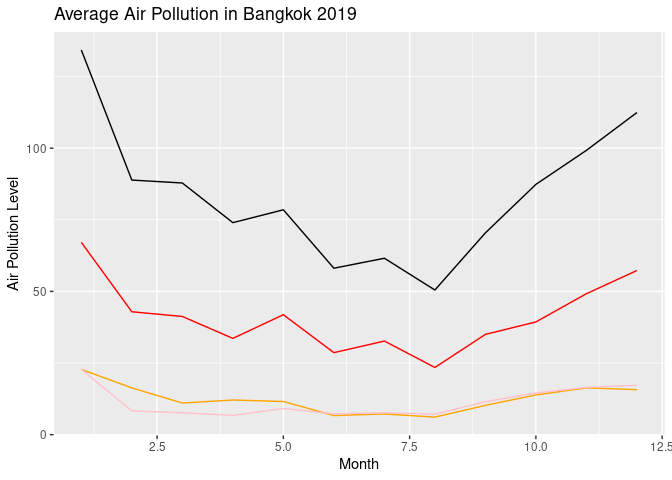

```r
ggplot(data=ro_ap19sum, aes(x=month, y=mean_pm25, group=1)) +
  geom_line()+
  geom_line(aes(x=month, y=mean_pm10), color = "red") +
  geom_line(aes(x=month, y=mean_o3), color = "orange") +
  geom_line(aes(x=month, y=mean_no2), color = "pink") +
  labs(title = "Average Air Pollution in Bangkok 2019", x = "Month", y = "Air Pollution Level") +
  theme(legend.position = c(10, 100),legend.justification = c(10, 100))
```

As we can see from the graph, the local winter season (from October to next year’s February) has overall higher air pollution in all of the four indexes. The reason is that when Bangkok is in winter, the air temperature will be lower. The density of cold air is higher than that of warm air, so cold air moves slower than warm air. Then the pollutants in the air also move slower in winter because they tend to accumulate and be trapped in the original area. Therefore, the air pollution in winter will be higher than summer, which usually has warmer air. We can also find that in Bangkok’s rainy seasons, the air pollution level is the lowest in a year. Besides the explanation from air density, I believe the precipitation and humidity could also be the reasons. The water can make the particulate matters accumulate and rush them to the ground, which makes the air more clear. As we can see from the graph, the PM2.5 and PM10 levels are decreased more than O3 and NO2. This is because O3 and NO2 are actually toxic air, not particulate matters. Therefore, they are hardly influenced in the rainy seasons. However, interaction of NO2 and SO2 will bring acid rain, which harms sensitive ecosystems in a large scale. We need to keep the toxic air in the least possible level.

Now I come to the comparison of air quality between 2019 and 2020. For the air pollution data of Bangkok in 2020, I first read the file and do some basic data cleaning, including selecting ideal columns for analysis and omitting NA values.

```r
ap20_raw <- read.csv("bangkok-air20.csv")
ap20_new <- dplyr::select(ap20_raw, c(-so2,-co))
ap20 <- na.omit(ap20_new)
head(ap20)
```

```
##         date pm25 pm10 o3 no2
## 1 October-20   56   21  7  12
## 2 October-20   48   25 12  14
## 3 October-20   57   18 11  12
## 4 October-20   43   23 10   9
## 5 October-20   58   26 12  12
## 6 October-20   68   28 12   9
```

Since we want to compare the overall air quality between 2019 and 2020 in Bangkok, we need to calculate the average level of each pollutants in both years and make a comparison. I will make a table to directly compare the pollution levels, and I expect the air quality in 2020 will be better than the air quality in 2019. In the table, if the average level of an air pollutant in 2020 is lower than 2019, it will have a “TRUE” answer.

```r
pm25_comparison <- mean(ap20$pm25) < mean(ap19$pm25)
pm10_comparison <- mean(ap20$pm10) < mean(ap19$pm10)
o3_comparison <- mean(ap20$o3) < mean(ap19$o3)
no2_comparison <- mean(ap20$no2) < mean(ap19$no2)
comparison <- data.frame(
  AQ_Index = c("PM2.5","PM10","O3","NO2"),
  Result = c(pm25_comparison,pm10_comparison,o3_comparison,no2_comparison))
comparison
```

```
##   AQ_Index Result
## 1    PM2.5   TRUE
## 2     PM10   TRUE
## 3       O3   TRUE
## 4      NO2   TRUE
```

We can clearly see that, all of the pollutant levels in 2020 is lower than 2019. It seems that under the COVID-19 pandemic, the air quality in Bangkok became better. Possible reasons behind this phenomenon is that under the COVID-19 quarantine requirements from the government, people go out less and use less transportation. Therefore, the air quality is better off.

For next part of analysis on the socio-economic factors behind the air pollution in Bangkok, I decide to use the shapefiles data from Thailand government. I will first download the data from the sources and store them into my R “work” directory. The data I am going to download and use are Bangkok’s map and according population level (multipolygons), the location of bikeways (multilinestrings), locations and quantities of waste centers (points), and locations of gas stations (points).

```r
dir.create("../work/shapefiles")
download.file("https://data.go.th/dataset/0199eb7f-6726-4947-8f98-e11652e82ae1/resource/090039e1-d33c-4341-a99a-cabe6916926d/download/waste_center.zip",
              "../work/shapefiles/waste_center.zip")
unzip("../work/shapefiles/waste_center.zip",
      exdir="..work/shapefiles/bangkok_waste")

download.file("https://data.go.th/dataset/04d564b5-b0db-48f9-ba41-b44b0422deec/resource/7c2c2c0b-1e7f-4437-b973-35308cb29f72/download/bike_way.zip",
              "../work/shapefiles/bike_way.zip")
unzip("../work/shapefiles/bike_way.zip",
      exdir="..work/shapefiles/bikeway")

download.file("https://data.go.th/dataset/663ed528-97d7-4dd2-a463-be865e6fda28/resource/22667479-6786-495a-8606-c9b1dc433af2/download/district.zip",
              "../work/shapefiles/district.zip")
unzip("../work/shapefiles/district.zip",
      exdir="..work/shapefiles/ds")

download.file("https://data.go.th/dataset/9f8ed877-dfd8-43ec-b13d-33c05fb8ba2c/resource/90871776-e514-41c5-955a-8f258bd6f8ca/download/oil_service.zip",
              "../work/shapefiles/oil_service.zip")
unzip("../work/shapefiles/oil_service.zip",
      exdir="..work/shapefiles/gas")
```

After downloading the data, I can begin to read and plot the data. For the second part of the below code chunk, I am trying to put the layers of gas stations, bikeways, and waste centers above the layer of Bangkok 50 districts map. The white to brown color bar represents the number of communities in each district of Bangkok, and it can show how many people live in this district. So, if the area is red, then there lives more residents then the white area. The gray circle represent the location of waste centers in Bangkok, and their size represent the quantities of waste centers in that district. The red points represent the gas station, and one point represents one gas station. I also draw the major bikeways in Bangkok, colored as green lines.

```r
bangkok <- st_read("..work/shapefiles/ds/")
waste <- st_read("..work/shapefiles/bangkok_waste/")
bw <- st_read("..work/shapefiles/bikeway/")
gs <- st_read("..work/shapefiles/gas/")
```

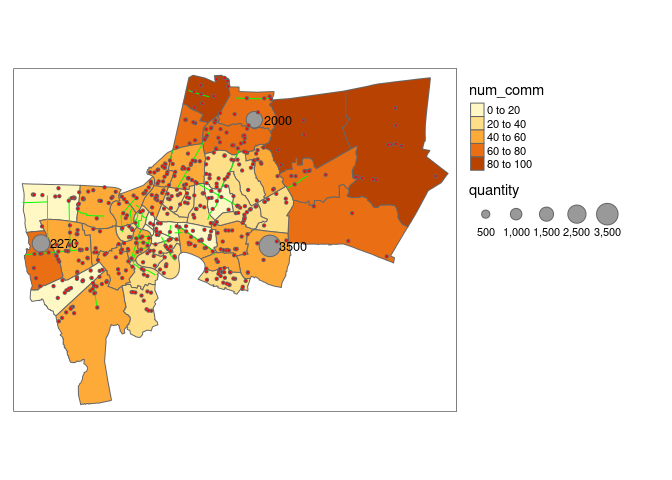

```r
tm_shape(bangkok) + tm_polygons(col = "num_comm")+
  tm_shape(waste) + tm_bubbles(size = "quantity", scale = 1.5) + tm_text("quantity", just = "left", xmod = 0.5, size = 0.8) +
  tm_shape(bw) + tm_lines(col = "green") +
  tm_shape(gs) + tm_bubbles(size=0.03, col = "red") +
  tm_legend(outside = TRUE)
```

As we can see from the image, the population is mostly in the right and left districts of Bangkok. Something good from the image is that in the right regions of Bangkok, which contain most of the population, we can see very few gas stations. Gas stations typically bring NO2 and SO2 to the atmosphere and harms the air quality. The small number of gas stations in the right regions will not bring too many negative impacts on the local air quality. Also, the waste centers are not in the right regions. However, we can see that the most of waste centers are still in the area which are highly populated (orange to red colors). This phenomenon reminds me of the concept of environmental justice, which means that some people, with lower education level, income level, worse communities, etc., will typically experience more environmental pollution than the people with high levels of income or education. People who live in these districts are usually in bad communities[1], and they needed to suffer from the pollution to the environment from these landfills. These areas are called the “Desperate Area” in Bangkok, and we really need to make efforts to solve this environmental injustice issue.

For the next part of analysis, I am going to research the natural factor that influence the air quality in Bangkok. I decide to dive into two factors, which are the geographical characteristics of Bangkok and weather here. First, I download the geographical raster data from Open Data Thailand.

```r
dir.create("../work/ls")
download.file("http://www.savgis.org/Thailand/DEM/ThaiDEM500_0000400000_0011200000.zip",
              "../work/ls/ThaiDEM500_0000400000_0011200000.zip")
unzip("../work/ls/ThaiDEM500_0000400000_0011200000.zip",
      exdir="..work/ls/Thails")

download.file("http://www.savgis.org/Thailand/Rainfall.zip",
              "../work/shapefiles/Rainfall.zip")
unzip("../work/shapefiles/Rainfall.zip",
      exdir="..work/shapefiles/rainfall")
```

After downloading the data, I can begin to plot the raster data by tmap method. First I plot the basic elevation graph of central Thailand region colored as “heated map”. The green area will have low elevation, namely the plain, and the red area will have high elevation, namely the mountainous areas. Bangkok is on the olive green area with very low elevation. There is also a color bar and quantile chart beside the image. The quantile chart is used to represent the distribution of elevations on this area.

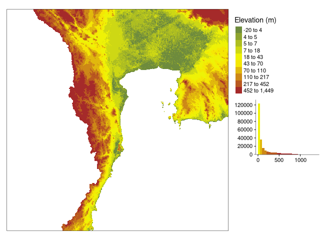

```r
area1 <- raster("..work/ls/Thails/ThaiDEM500_0000400000_0011200000.asc")
tm_shape(area1) +
  tm_raster(style = "quantile", n = 10, title = "Elevation (m)",
            palette = colorRampPalette( c("darkolivegreen4","yellow", "brown"))(10),
            legend.hist = TRUE)+
  tm_legend(outside = TRUE, hist.width = 5)
```

Besides the geography, I am going to research the relationship between local weather and air quality. At the beginning, I need to use my API key to call Bangkok weather data from Open Weather Map. The city ID of Bangkok is 1609348, and I choose to extract the monthly aggregated data for year 2020 from this platform. After extracting them, I prepare them to the JSON format for further analysis. I store the raw JSON data into m1, m2, m3, etc. which means month 1, month 2, month 3, etc. to make tables.

```r
dm1 <- GET("history.openweathermap.org/data/2.5/aggregated/month?id=1609348&month=1&appid=e969380692a03d6dee11c0a5cf7bc5e3")
m1 <- fromJSON(rawToChar(dm1$content))
dm2 <- GET("history.openweathermap.org/data/2.5/aggregated/month?id=1609348&month=2&appid=e969380692a03d6dee11c0a5cf7bc5e3")
m2 <- fromJSON(rawToChar(dm2$content))
dm3 <- GET("history.openweathermap.org/data/2.5/aggregated/month?id=1609348&month=3&appid=e969380692a03d6dee11c0a5cf7bc5e3")
m3 <- fromJSON(rawToChar(dm3$content))
dm4 <- GET("history.openweathermap.org/data/2.5/aggregated/month?id=1609348&month=4&appid=e969380692a03d6dee11c0a5cf7bc5e3")
m4 <- fromJSON(rawToChar(dm4$content))
dm5 <- GET("history.openweathermap.org/data/2.5/aggregated/month?id=1609348&month=5&appid=e969380692a03d6dee11c0a5cf7bc5e3")
m5 <- fromJSON(rawToChar(dm5$content))
dm6 <- GET("history.openweathermap.org/data/2.5/aggregated/month?id=1609348&month=6&appid=e969380692a03d6dee11c0a5cf7bc5e3")
m6 <- fromJSON(rawToChar(dm6$content))
dm7 <- GET("history.openweathermap.org/data/2.5/aggregated/month?id=1609348&month=7&appid=e969380692a03d6dee11c0a5cf7bc5e3")
m7 <- fromJSON(rawToChar(dm7$content))
dm8 <- GET("history.openweathermap.org/data/2.5/aggregated/month?id=1609348&month=8&appid=e969380692a03d6dee11c0a5cf7bc5e3")
m8 <- fromJSON(rawToChar(dm8$content))
dm9 <- GET("history.openweathermap.org/data/2.5/aggregated/month?id=1609348&month=9&appid=e969380692a03d6dee11c0a5cf7bc5e3")
m9 <- fromJSON(rawToChar(dm9$content))
dm10 <- GET("history.openweathermap.org/data/2.5/aggregated/month?id=1609348&month=10&appid=e969380692a03d6dee11c0a5cf7bc5e3")
m10 <- fromJSON(rawToChar(dm10$content))
dm11 <- GET("history.openweathermap.org/data/2.5/aggregated/month?id=1609348&month=11&appid=e969380692a03d6dee11c0a5cf7bc5e3")
m11 <- fromJSON(rawToChar(dm11$content))
dm12 <- GET("history.openweathermap.org/data/2.5/aggregated/month?id=1609348&month=12&appid=e969380692a03d6dee11c0a5cf7bc5e3")
m12 <- fromJSON(rawToChar(dm12$content))
```

Below, I am trying to create a table to show the average humidity, average wind speed, and average precipitation by twelve months in 2020. This table will be convenient when merging with the table of air pollution data before.

```r
month <- c(1,2,3,4,5,6,7,8,9,10,11,12)
mean_humidity <- c(m1[["result"]][["humidity"]][["mean"]],m2[["result"]][["humidity"]][["mean"]],m3[["result"]][["humidity"]][["mean"]],m4[["result"]][["humidity"]][["mean"]],
                   m5[["result"]][["humidity"]][["mean"]],m6[["result"]][["humidity"]][["mean"]],m7[["result"]][["humidity"]][["mean"]],m8[["result"]][["humidity"]][["mean"]],
                   m9[["result"]][["humidity"]][["mean"]],m10[["result"]][["humidity"]][["mean"]],m11[["result"]][["humidity"]][["mean"]],m12[["result"]][["humidity"]][["mean"]])
mean_windspeed <- c(m1[["result"]][["wind"]][["mean"]],m2[["result"]][["wind"]][["mean"]],m3[["result"]][["wind"]][["mean"]],m4[["result"]][["wind"]][["mean"]],
                   m5[["result"]][["wind"]][["mean"]],m6[["result"]][["wind"]][["mean"]],m7[["result"]][["wind"]][["mean"]],m8[["result"]][["wind"]][["mean"]],
                   m9[["result"]][["wind"]][["mean"]],m10[["result"]][["wind"]][["mean"]],m11[["result"]][["wind"]][["mean"]],m12[["result"]][["wind"]][["mean"]])
mean_precipitation <- c(m1[["result"]][["precipitation"]][["mean"]],m2[["result"]][["precipitation"]][["mean"]],m3[["result"]][["precipitation"]][["mean"]],m4[["result"]][["precipitation"]][["mean"]],
                   m5[["result"]][["precipitation"]][["mean"]],m6[["result"]][["precipitation"]][["mean"]],m7[["result"]][["precipitation"]][["mean"]],m8[["result"]][["precipitation"]][["mean"]],
                   m9[["result"]][["precipitation"]][["mean"]],m10[["result"]][["precipitation"]][["mean"]],m11[["result"]][["precipitation"]][["mean"]],m12[["result"]][["precipitation"]][["mean"]])
weather_data2020 <- data.frame(month,mean_humidity,mean_windspeed,mean_precipitation)
weather_data2020
```

```
##    month mean_humidity mean_windspeed mean_precipitation
## 1      1         63.79           2.69               0.04
## 2      2         63.88           3.07               0.04
## 3      3         68.26           3.77               0.08
## 4      4         68.24           3.56               0.07
## 5      5         69.42           3.33               0.09
## 6      6         72.73           3.33               0.18
## 7      7         72.55           3.45               0.10
## 8      8         73.70           3.38               0.13
## 9      9         78.25           2.85               0.20
## 10    10         79.40           2.43               0.22
## 11    11         69.33           2.69               0.09
## 12    12         62.41           2.80               0.03
```

As I just prepared the data for air pollution in 2019, I need to make some quick and basic data cleaning for the 2020 air quality dataset, including grouping, calculating the average pollution level in each month, and rearranging the dataset.

```r
ap20sum <- ap20 %>%
  group_by(date) %>%
  summarise(mean_pm25 = mean(pm25),mean_pm10 = mean(pm10),mean_o3 = mean(o3),mean_no2 = mean(no2))

month20 <- c(4,8,12,2,1,7,6,3,5,11,10,9)
itm20 <- ap20sum %>% add_column(month = month20)
ro_ap20sum <- arrange(dplyr::select(itm20[, c(6,1,2,3,4,5)],-date), month20)
```

After cleaning the data, I can merge the weather data in 2020 with the air pollution 2020 data together, and I get the “summary” table. It will be convenient for correlation analysis.

```r
summary <- merge(x = ro_ap20sum, y = weather_data2020, by="month",all=TRUE)
summary
```

```
##    month mean_pm25 mean_pm10   mean_o3  mean_no2 mean_humidity mean_windspeed
## 1      1 120.73333  60.13333 13.966667 14.833333         63.79           2.69
## 2      2 126.68966  64.79310 16.827586 11.965517         63.88           3.07
## 3      3  79.00000  37.89655 10.000000  5.931034         68.26           3.77
## 4      4  73.13793  33.41379 13.344828  5.517241         68.24           3.56
## 5      5  61.70968  27.67742 10.741935  4.161290         69.42           3.33
## 6      6  48.93333  21.30000  9.433333  5.933333         72.73           3.33
## 7      7  52.09677  23.22581 10.580645  6.645161         72.55           3.45
## 8      8  53.41935  25.32258  7.225806  5.870968         73.70           3.38
## 9      9  51.20000  24.83333  8.666667  6.833333         78.25           2.85
## 10    10  68.12903  32.70968  9.677419 13.645161         79.40           2.43
## 11    11  87.86667  43.86667 17.333333 15.066667         69.33           2.69
## 12    12 104.12903  52.48387 18.161290 18.709677         62.41           2.80
##    mean_precipitation
## 1                0.04
## 2                0.04
## 3                0.08
## 4                0.07
## 5                0.09
## 6                0.18
## 7                0.10
## 8                0.13
## 9                0.20
## 10               0.22
## 11               0.09
## 12               0.03
```

Below, I am trying to create three graphs which explore the relationships between different weather conditions (humidity, wind speed, and precipitation) and air pollutants. They will be dot plots. The x axis will be a certain weather condition, and the y axis will be the pollution level for these four air pollutants. In each graph, the cadet blue dots will be average PM2.5; the violet dots will be average PM10, the green yellow dots will be average O3, and the black dots will be average NO2.

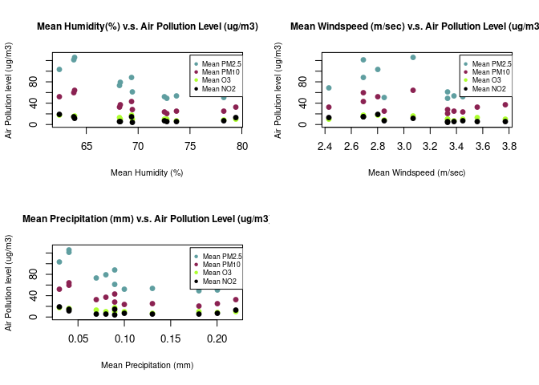

```r
par(mfrow = c(2,2))

plot(summary$mean_humidity,summary$mean_pm25,col = "cadetblue",xlab="Mean Humidity (%)", ylab="Air Pollution level (ug/m3)",ylim=c(0,130), pch="●",cex.lab=0.8)
points(summary$mean_humidity, summary$mean_pm10, col="violetred4",pch="●")
points(summary$mean_humidity, summary$mean_o3, col="greenyellow",pch="●")
points(summary$mean_humidity, summary$mean_no2, col="black",pch="●")
title("Mean Humidity(%) v.s. Air Pollution Level (ug/m3)", cex.main=0.9)
legend(75,130,legend=c("Mean PM2.5","Mean PM10","Mean O3","Mean NO2"), col=c("cadetblue","violetred4","greenyellow", "black"), pch=c("●","●","●","●","●"), ncol=1, cex=0.65)

plot(summary$mean_windspeed,summary$mean_pm25,col = "cadetblue",xlab="Mean Windspeed (m/sec)", ylab="Air Pollution level (ug/m3)",ylim=c(0,130), pch="●",cex.lab=0.8)
points(summary$mean_windspeed, summary$mean_pm10, col="violetred4",pch="●")
points(summary$mean_windspeed, summary$mean_o3, col="greenyellow",pch="●")
points(summary$mean_windspeed, summary$mean_no2, col="black",pch="●")
title("Mean Windspeed (m/sec) v.s. Air Pollution Level (ug/m3)",cex.main = 0.9)
legend(3.425,130,legend=c("Mean PM2.5","Mean PM10","Mean O3","Mean NO2"), col=c("cadetblue","violetred4","greenyellow", "black"), pch=c("●","●","●","●","●"), ncol=1,cex=0.65)

plot(summary$mean_precipitation,summary$mean_pm25,col = "cadetblue",xlab="Mean Precipitation (mm)", ylab="Air Pollution level (ug/m3)",ylim=c(0,130), pch="●",cex.lab=0.8)
points(summary$mean_precipitation, summary$mean_pm10, col="violetred4",pch="●")
points(summary$mean_precipitation, summary$mean_o3, col="greenyellow",pch="●")
points(summary$mean_precipitation, summary$mean_no2, col="black",pch="●")
title("Mean Precipitation (mm) v.s. Air Pollution Level (ug/m3)",cex.main = 0.9)
legend(0.171,130,legend=c("Mean PM2.5","Mean PM10","Mean O3","Mean NO2"), col=c("cadetblue","violetred4","greenyellow", "black"), pch=c("●","●","●","●","●"), ncol=1,cex=0.65)
```

From the result graph, what we can see is that the air pollution and weather conditions seem to be in negative relationships. In other words, with the increase of humidity/wind speed/precipitation, the air pollution level will decrease. For average wind speed v.s. air pollution level, their relationship is less clear. Therefore, I decide to make a table to show each of the correlation coefficient and check the whether the correlation coefficient matters scientifically. Hope there can be something interesting.

```r
ctbl <- data.frame(
  AQ_Index = c("PM2.5","PM10","O3","NO2"),
  Mean_Humidity = c(cor(summary$mean_humidity,summary$mean_pm25),cor(summary$mean_humidity,summary$mean_pm10),cor(summary$mean_humidity,summary$mean_o3),cor(summary$mean_humidity,summary$mean_no2)),
  Mean_Windspeed = c(cor(summary$mean_windspeed,summary$mean_pm25),cor(summary$mean_windspeed,summary$mean_pm10),cor(summary$mean_windspeed,summary$mean_o3),cor(summary$mean_windspeed,summary$mean_no2)),
  Mean_Precipitation = c(cor(summary$mean_precipitation,summary$mean_pm25),cor(summary$mean_precipitation,summary$mean_pm10),cor(summary$mean_precipitation,summary$mean_o3),cor(summary$mean_precipitation,summary$mean_no2))
  )
ctbl
```

```
##   AQ_Index Mean_Humidity Mean_Windspeed Mean_Precipitation
## 1    PM2.5    -0.7978960     -0.3633463         -0.7298353
## 2     PM10    -0.7747959     -0.3938262         -0.7065819
## 3       O3    -0.7663256     -0.3601008         -0.7171954
## 4      NO2    -0.4060645     -0.7878014         -0.3167795
```

#Summary

From this project, I successfully explore the factors behind the air pollution in Bangkok. I have seen the socio-economic factors like the construction of infrastructures and natural factors like the geography and local weather conditions. They all play roles in the local air quality. However, I also witness the environmental injustice in Bangkok, and after searching on the internet, I do find many articles on the desperation of local people about their unfair life conditions. Everyone in every part of the world has the rights to enjoy clean air, water, or space. I hope the local governments can take more feasible actions to solve the local air quality and environment injustice issue in a scientific and fair way, such as applying United Nations’ 17 Sustainable Development Goals into their daily work.

#Reference:

[1]. Winn, Patrick. “Bangkok: A City of Glitz, A City of Desperation.” World. npr. 2013. https://www.npr.org/2013/01/15/169439486/bangkok-a-city-of-glitz-a-city-of-desperation

[2]. “Correlation Coefficient: Simple Definition, Formula, Easy Steps.” Statistics How to. 2018. https://www.statisticshowto.com/probability-and-statistics/correlation-coefficient-formula/